# Lab6_McMullen

Jared McMullen

11/5/2021

# Problem 1

```r
library(readr)
insurance <- read_csv("~/Downloads/insurance_costs_1 (1).csv")
datatable(insurance)
```

|  | age | sex | bmi | smoker | region | charges |
| --- | --- | --- | --- | --- | --- | --- |
| 1 | 19 | female | 27.9 | yes | southwest | 16884.924 |
| 2 | 33 | male | 22.705 | no | northwest | 21984.47061 |
| 3 | 32 | male | 28.88 | no | northwest | 3866.8552 |
| 4 | 31 | female | 25.74 | no | southeast | 3756.6216 |
| 5 | 60 | female | 25.84 | no | northwest | 28923.13692 |
| 6 | 25 | male | 26.22 | no | northeast | 2721.3208 |
| 7 | 62 | female | 26.29 | yes | southeast | 27808.7251 |
| 8 | 56 | female | 39.82 | no | southeast | 11090.7178 |
| 9 | 27 | male | 42.13 | yes | southeast | 39611.7577 |
| 10 | 23 | male | 23.845 | no | northeast | 2395.17155 |

[output cut: 421 more lines]

```r
#Provide summary of
summary(insurance)
```

```
##       age            sex                 bmi           smoker
##  Min.   :18.00   Length:431         Min.   :15.96   Length:431
##  1st Qu.:22.00   Class :character   1st Qu.:26.36   Class :character
##  Median :34.00   Mode  :character   Median :30.59   Mode  :character
##  Mean   :37.96                      Mean   :30.77
##  3rd Qu.:55.00                      3rd Qu.:35.27
##  Max.   :64.00                      Max.   :49.06
##     region             charges
##  Length:431         Min.   : 1132
##  Class :character   1st Qu.: 2710
##  Mode  :character   Median : 9866
##                     Mean   :12297
##                     3rd Qu.:14511
##                     Max.   :55135
```

```r
#Clean the data
insurance <- insurance %>%
  na.omit(insurance) %>%
  mutate(
    charges = round(charges, digits = 0),
    bmi = round(bmi, digits = 1)
  )
```

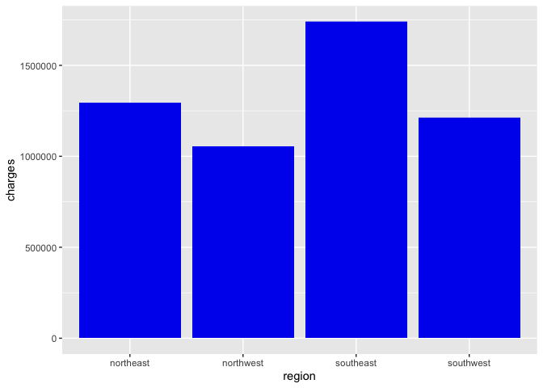

```r
#region vs charges
insurance %>%
  ggplot(aes(y = charges, x = region)) +
  geom_bar(stat = "identity", fill="blue2")
```

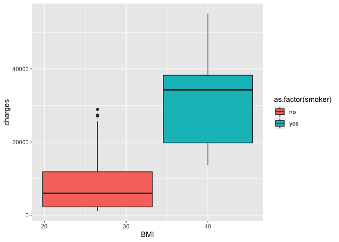

```r
#BMI vs charges
insurance %>%
  ggplot(aes(x= bmi, y = charges, fill = as.factor(smoker))) +
  geom_boxplot() +
  xlab("BMI")
```

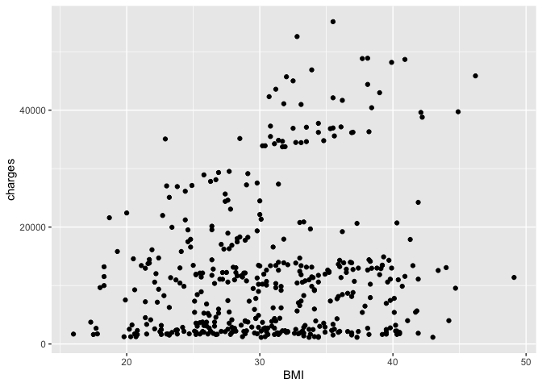

```r
#smoker vs charges
insurance %>%
  ggplot(aes(y= charges, x = bmi)) +
  geom_point( fill = "blue2") +
  xlab("BMI")
```

From the first graph you can tell whether the regions have drastic affect on where the charges are held. From the bar plot you can see that most of the regions are relatively similar in distribution besides the southeast. This makes us question whether region will have any real prediction on where charges may be higher. The second graph shows us how smoking and BMI relate to charges. And you can see that if someone is a smoker, they are likely to have a higher BMI and also incur higher charges for insurance. This leads us to believe that they will be great predictors when generating models. Lastly, we have a scatterplot showing the relation of BMI with charges. It is evident that as BMI increases, so does the charges. But this isnt necessarily true for everyone as there looks like two relationships seen on the graph. On top of all the low charge scores there is a line increases in charges as BMI goes up. This makes us believe there must be another variable present to justify this change.

# Part 2

```r
lr_model <- linear_reg() %>%
  set_mode("regression") %>%
  set_engine("lm")

model1 <- lr_model %>%
  fit(charges ~ age, data = insurance)
summary(model1$fit)
```

```
##
## Call:
## stats::lm(formula = charges ~ age, data = data)
##
## Residuals:
##    Min     1Q Median     3Q    Max
##  -7458  -6490  -5628   4154  43973
##
## Coefficients:
##             Estimate Std. Error t value Pr(>|t|)
## (Intercept)  3611.78    1374.39   2.628   0.0089 **
## age           228.80      33.25   6.880 2.12e-11 ***
## ---
## Signif. codes:  0 '***' 0.001 '**' 0.01 '*' 0.05 '.' 0.1 ' ' 1
##
## Residual standard error: 11280 on 429 degrees of freedom
## Multiple R-squared:  0.09938,    Adjusted R-squared:  0.09728
## F-statistic: 47.34 on 1 and 429 DF,  p-value: 2.124e-11
```

```r
model2 <- lr_model %>%
  fit(charges ~ age + sex, data = insurance)
summary(model2$fit)
```

```
##
## Call:
## stats::lm(formula = charges ~ age + sex, data = data)
##
## Residuals:
##    Min     1Q Median     3Q    Max
##  -7799  -6472  -5586   4177  44282
##
## Coefficients:
##             Estimate Std. Error t value Pr(>|t|)
## (Intercept)  3315.37    1462.40   2.267   0.0239 *
## age           228.43      33.28   6.863 2.38e-11 ***
## sexmale       649.80    1089.14   0.597   0.5511
## ---
## Signif. codes:  0 '***' 0.001 '**' 0.01 '*' 0.05 '.' 0.1 ' ' 1
##
## Residual standard error: 11290 on 428 degrees of freedom
## Multiple R-squared:  0.1001, Adjusted R-squared:  0.09592
## F-statistic: 23.81 on 2 and 428 DF,  p-value: 1.565e-10
```

```r
model3 <- lr_model %>%
  fit(charges ~ age + smoker, data = insurance)
summary(model3$fit)
```

```
##
## Call:
## stats::lm(formula = charges ~ age + smoker, data = data)
##
## Residuals:
##      Min       1Q   Median       3Q      Max
## -15680.6  -1730.6  -1021.1   -174.5  24899.2
##
## Coefficients:
##             Estimate Std. Error t value Pr(>|t|)
## (Intercept) -2166.84     729.39  -2.971  0.00314 **
## age           253.14      17.19  14.729  < 2e-16 ***
## smokeryes   24048.90     699.89  34.361  < 2e-16 ***
## ---
## Signif. codes:  0 '***' 0.001 '**' 0.01 '*' 0.05 '.' 0.1 ' ' 1
##
## Residual standard error: 5827 on 428 degrees of freedom
## Multiple R-squared:  0.7604, Adjusted R-squared:  0.7593
## F-statistic: 679.1 on 2 and 428 DF,  p-value: < 2.2e-16
```

```r
#MSE of model2
extract <- summary(model2$fit)
e2 <-residuals(extract)
MSE2 <- mean(e2^2)
MSE2
```

```
## [1] 126634007
```

```r
#MSE of model3
extract <- summary(model3$fit)
e3 <-residuals(extract)
MSE3 <- mean(e3^2)
MSE3
```

```
## [1] 33719602
```

```r
#Create a df to visualize the fit of the models
df <- data.frame(
  Model_num = c("Model2", "Model3"),
  MSE = c(126633999, 33719831),
  R_squared = c(0.1001, 0.7604)
)
datatable(df)
```

|  | Model_num | MSE | R_squared |
| --- | --- | --- | --- |
| 1 | Model2 | 126633999 | 0.1001 |
| 2 | Model3 | 33719831 | 0.7604 |

From this comparison between the models we know that we want to choose the model that posses-es the best goodness of fit (highest r-squared value), and the lowest MSE. From the table above, we can quickly identify that model3 is by a large margin the best model to fit the data.

# Part 3

```r
model4 <- lr_model %>%
  fit(charges ~ age + bmi, data = insurance)
summary(model4$fit)
```

```
##
## Call:
## stats::lm(formula = charges ~ age + bmi, data = data)
##
## Residuals:
##    Min     1Q Median     3Q    Max
## -10819  -6722  -4979   3307  42571
##
## Coefficients:
##             Estimate Std. Error t value Pr(>|t|)
## (Intercept) -4631.86    2917.16  -1.588  0.11307
## age           216.30      33.13   6.528 1.89e-10 ***
## bmi           283.34      88.70   3.194  0.00151 **
## ---
## Signif. codes:  0 '***' 0.001 '**' 0.01 '*' 0.05 '.' 0.1 ' ' 1
##
## Residual standard error: 11160 on 428 degrees of freedom
## Multiple R-squared:  0.1204, Adjusted R-squared:  0.1162
## F-statistic: 29.28 on 2 and 428 DF,  p-value: 1.209e-12
```

```r
#MSE for Model4
extract <- summary(model4$fit)
e4 <-residuals(extract)
MSE4 <- mean(e4^2)
MSE4
```

```
## [1] 123788355
```

```r
#Create a df
df <- data.frame(
  Model_num = c("Model1", "Model4"),
  MSE = c(126739317, 123792440),
  Adj_R_squared = c(0.09728,0.1162)
)
datatable(df)
```

|  | Model_num | MSE | Adj_R_squared |
| --- | --- | --- | --- |
| 1 | Model1 | 126739317 | 0.09728 |
| 2 | Model4 | 123792440 | 0.1162 |

It is clear that when BMI is introduced with age as a predictor variable, the MSE is lower and the Adjusted R^2 is slightly higher in value, making this new model4 a better model for the data.

```r
model5 <- lr_model %>%
  fit(charges ~ age + I(age^2), data = insurance)
summary(model5$fit)
```

```
##
## Call:
## stats::lm(formula = charges ~ age + I(age^2), data = data)
##
## Residuals:
##    Min     1Q Median     3Q    Max
##  -7705  -6520  -5660   4173  43748
##
## Coefficients:
##             Estimate Std. Error t value Pr(>|t|)
## (Intercept) 2299.891   4413.849   0.521    0.603
## age          308.419    256.705   1.201    0.230
## I(age^2)      -1.001      3.201  -0.313    0.755
##
## Residual standard error: 11300 on 428 degrees of freedom
## Multiple R-squared:  0.09959,    Adjusted R-squared:  0.09538
## F-statistic: 23.67 on 2 and 428 DF,  p-value: 1.781e-10
```

```r
#MSE for Model4
extract <- summary(model5$fit)
e5 <-residuals(extract)
MSE5 <- mean(e5^2)
MSE5
```

```
## [1] 126710358
```

```r
#Create a df
df <- data.frame(
  Model_num = c("Model1", "Model5"),
  MSE = c(126739317, 126710294),
  Adj_R_squared = c(0.09728,0.09538)
)
datatable(df)
```

|  | Model_num | MSE | Adj_R_squared |
| --- | --- | --- | --- |
| 1 | Model1 | 126739317 | 0.09728 |
| 2 | Model5 | 126710294 | 0.09538 |

As you can see from the table above, when the relationship is quadratic with age, the model is actually a worse fit, as seen by the decreased Adjusted R-squared value, and practically identical MSE value.

```r
model6 <- lr_model %>%
  fit(charges ~ poly(age, 4), data = insurance)
summary(model6$fit)
```

```
##
## Call:
## stats::lm(formula = charges ~ poly(age, 4), data = data)
##
## Residuals:
##    Min     1Q Median     3Q    Max
##  -9314  -6435  -5354   4640  42680
##
## Coefficients:
##               Estimate Std. Error t value Pr(>|t|)
## (Intercept)    12297.1      542.9  22.652  < 2e-16 ***
## poly(age, 4)1  77638.0    11270.5   6.889 2.03e-11 ***
## poly(age, 4)2  -3533.4    11270.5  -0.314   0.7540
## poly(age, 4)3   8004.0    11270.5   0.710   0.4780
## poly(age, 4)4  20877.3    11270.5   1.852   0.0647 .
## ---
## Signif. codes:  0 '***' 0.001 '**' 0.01 '*' 0.05 '.' 0.1 ' ' 1
##
## Residual standard error: 11270 on 426 degrees of freedom
## Multiple R-squared:  0.1078, Adjusted R-squared:  0.09945
## F-statistic: 12.87 on 4 and 426 DF,  p-value: 6.685e-10
```

```r
#MSE for Model6
extract <- summary(model6$fit)
e6 <-residuals(extract)
MSE6 <- mean(e6^2)
MSE6
```

```
## [1] 125550437
```

```r
#Create a df
df <- data.frame(
  Model_num = c("Model1", "Model6"),
  MSE = c(126739317, 125550390),
  R_squared = c(0.09728,0.1078)
)
datatable(df)
```

|  | Model_num | MSE | R_squared |
| --- | --- | --- | --- |
| 1 | Model1 | 126739317 | 0.09728 |
| 2 | Model6 | 125550390 | 0.1078 |

From the table you can tell that once the polynomial model is introduced, the MSE value is lower and the R-squared value is higher, meaning that it is in fact a better fit for the data.

```r
model7 <- lr_model %>%
  fit(charges ~ poly(age, 12), data = insurance)
summary(model7$fit)
```

```
##
## Call:
## stats::lm(formula = charges ~ poly(age, 12), data = data)
##
## Residuals:
##    Min     1Q Median     3Q    Max
## -10120  -6922  -4672   3492  42482
##
## Coefficients:
##                 Estimate Std. Error t value Pr(>|t|)
## (Intercept)      12297.1      544.5  22.586  < 2e-16 ***
## poly(age, 12)1   77638.0    11303.3   6.869 2.36e-11 ***
## poly(age, 12)2   -3533.4    11303.3  -0.313   0.7547
## poly(age, 12)3    8004.0    11303.3   0.708   0.4793
## poly(age, 12)4   20877.3    11303.3   1.847   0.0655 .
## poly(age, 12)5    -696.2    11303.3  -0.062   0.9509
## poly(age, 12)6    4306.8    11303.3   0.381   0.7034
## poly(age, 12)7  -11402.8    11303.3  -1.009   0.3137
## poly(age, 12)8   -4046.4    11303.3  -0.358   0.7205
## poly(age, 12)9   12242.8    11303.3   1.083   0.2794
## poly(age, 12)10   6463.9    11303.3   0.572   0.5677
## poly(age, 12)11  12674.6    11303.3   1.121   0.2628
## poly(age, 12)12 -13734.2    11303.3  -1.215   0.2250
## ---
## Signif. codes:  0 '***' 0.001 '**' 0.01 '*' 0.05 '.' 0.1 ' ' 1
##
## Residual standard error: 11300 on 418 degrees of freedom
## Multiple R-squared:  0.1195, Adjusted R-squared:  0.0942
## F-statistic: 4.726 on 12 and 418 DF,  p-value: 2.951e-07
```

```r
#MSE for Model6
extract <- summary(model7$fit)
e7 <-residuals(extract)
MSE7 <- mean(e7^2)
MSE7
```

```
## [1] 123911523
```

```r
#Create a df
df <- data.frame(
  Model_num = c("Model1", "Model7"),
  MSE = c(126739317, 123911481),
  R_squared = c(0.09728,0.1195)
)
datatable(df)
```

|  | Model_num | MSE | R_squared |
| --- | --- | --- | --- |
| 1 | Model1 | 126739317 | 0.09728 |
| 2 | Model7 | 123911481 | 0.1195 |

```r
df <- data.frame(
  Model_num = c("Model1", "Model6", "Model7"),
  MSE = c(126739317, 125550390,123911481),
  R_squared = c(0.09728,0.1078, 0.1195)
)
datatable(df)
```

|  | Model_num | MSE | R_squared |
| --- | --- | --- | --- |
| 1 | Model1 | 126739317 | 0.09728 |
| 2 | Model6 | 125550390 | 0.1078 |
| 3 | Model7 | 123911481 | 0.1195 |

From the table it is evident that Model7 is the best model when comparing age linearly versus degrees of polynomials. So we can therefore infer that a a polynomial model fits the data more appropriately. This is determined by the lowest MSE value, and the highest R-squared value, which determines the goodness of fit for the model.

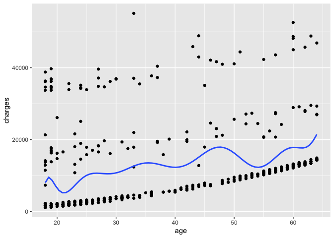

```r
insurance %>%
  ggplot(aes(x= age, y = charges)) +
  geom_point() +
  stat_smooth(method = "lm", formula = y ~ poly(x, 12), se = FALSE)
```

# Part 4

```r
library(readr)
insurance2 <- read_csv("~/Downloads/insurance_costs_2.csv")
datatable(insurance2)
```

|  | age | sex | bmi | smoker | region | charges |
| --- | --- | --- | --- | --- | --- | --- |
| 1 | 23 | male | 34.4 | no | southwest | 1826.843 |
| 2 | 56 | male | 40.3 | no | southwest | 10602.385 |
| 3 | 18 | male | 34.1 | no | southeast | 1137.011 |
| 4 | 63 | female | 23.085 | no | northeast | 14451.83515 |
| 5 | 63 | male | 28.31 | no | northwest | 13770.0979 |
| 6 | 19 | male | 20.425 | no | northwest | 1625.43375 |
| 7 | 60 | female | 24.53 | no | southeast | 12629.8967 |
| 8 | 18 | female | 35.625 | no | northeast | 2211.13075 |
| 9 | 40 | female | 36.19 | no | southeast | 5920.1041 |
| 10 | 46 | female | 27.74 | no | northwest | 8026.6666 |

[output cut: 133 more lines]

```r
model1 <- lr_model %>%
  fit(charges ~ age, data = insurance)
model2 <- lr_model %>%
  fit(charges ~ age + bmi, data = insurance)
model3 <- lr_model %>%
  fit(charges ~ age + bmi + smoker, data = insurance)
model4 <- lr_model %>%
  fit(charges ~ (age + bmi):smoker, data = insurance)
model5 <- lr_model %>%
  fit(charges ~ (age + bmi)*smoker, data = insurance)
```

```r
insurance2<- insurance2 %>%
  mutate(
    Pred1 = predict(model1,
                    new_data = insurance2,
                    type = "raw"),
    Pred2 = predict(model2,
                    new_data = insurance2,
                    type = "raw"),
    Pred3 = predict(model3,
                    new_data = insurance2,
                    type = "raw"),
    Pred4 = predict(model4,
                    new_data = insurance2,
                    type = "raw"),
    Pred5 = predict(model5,
                    new_data = insurance2,
                    type = "raw"),
    MSE1 = (Pred1 - charges)^2,
    MSE2 = (Pred2 - charges)^2,
    MSE3 = (Pred3 - charges)^2,
    MSE4 = (Pred4 - charges)^2,
    MSE5 = (Pred5 - charges)^2
  )

MSE1 <- round(mean(insurance2$MSE1), digits = 0)
MSE2 <- round(mean(insurance2$MSE2), digits = 0)
MSE3 <- round(mean(insurance2$MSE3), digits = 0)
MSE4 <- round(mean(insurance2$MSE4), digits = 0)
MSE5 <- round(mean(insurance2$MSE5), digits = 0)

df <- data.frame(
  Model_num = c("Model1", "Model2", "Model3", "Model4", "Model5"),
  MSE = c(MSE1, MSE2, MSE3, MSE4, MSE5)
)

datatable(df)
```

|  | Model_num | MSE |
| --- | --- | --- |
| 1 | Model1 | 136077147 |
| 2 | Model2 | 132635997 |
| 3 | Model3 | 35377857 |
| 4 | Model4 | 24800407 |
| 5 | Model5 | 21791479 |

From the table, we can determine that the MSE that is the lowest is for model5. It seems that as the model number goes up, the MSE value drops. If the best model to use is model 5, then when both age and BMI come from a smoker or a non smoker, a better prediction can be made about the charges someone will receive.

```r
insurance <- read_csv("~/Downloads/insurance_costs_1 (1).csv")
insurance2 <- read_csv("~/Downloads/insurance_costs_2.csv")
#Need to combine both of the data sets
combinedinsurance <- full_join(insurance, insurance2)
datatable(combinedinsurance)
```

|  | age | sex | bmi | smoker | region | charges |
| --- | --- | --- | --- | --- | --- | --- |
| 1 | 19 | female | 27.9 | yes | southwest | 16884.924 |
| 2 | 33 | male | 22.705 | no | northwest | 21984.47061 |
| 3 | 32 | male | 28.88 | no | northwest | 3866.8552 |
| 4 | 31 | female | 25.74 | no | southeast | 3756.6216 |
| 5 | 60 | female | 25.84 | no | northwest | 28923.13692 |
| 6 | 25 | male | 26.22 | no | northeast | 2721.3208 |
| 7 | 62 | female | 26.29 | yes | southeast | 27808.7251 |
| 8 | 56 | female | 39.82 | no | southeast | 11090.7178 |
| 9 | 27 | male | 42.13 | yes | southeast | 39611.7577 |
| 10 | 23 | male | 23.845 | no | northeast | 2395.17155 |

[output cut: 564 more lines]

```r
#Create 5-Fold Cross-validation
combinedinsurance_cvs <- vfold_cv(combinedinsurance, v = 5)

#Model 1 Test
model1_cv <- lr_model %>%
  fit_resamples(charges ~ age, resamples = combinedinsurance_cvs)

model1_cv %>% collect_metrics()
```

```
## # A tibble: 2 × 6
##   .metric .estimator      mean     n  std_err .config
##   <chr>   <chr>          <dbl> <int>    <dbl> <chr>
## 1 rmse    standard   11367.        5 466.     Preprocessor1_Model1
## 2 rsq     standard       0.114     5   0.0262 Preprocessor1_Model1
```

```r
#Model 2 Test

model2_cv <- lr_model %>%
  fit_resamples(charges ~ age + bmi, resamples = combinedinsurance_cvs)

model2_cv %>% collect_metrics()
```

```
## # A tibble: 2 × 6
##   .metric .estimator      mean     n  std_err .config
##   <chr>   <chr>          <dbl> <int>    <dbl> <chr>
## 1 rmse    standard   11274.        5 410.     Preprocessor1_Model1
## 2 rsq     standard       0.129     5   0.0265 Preprocessor1_Model1
```

```r
#Model 3 Test

model3_cv <- lr_model %>%
  fit_resamples(charges ~ age + bmi + smoker, resamples = combinedinsurance_cvs)

model3_cv %>% collect_metrics()
```

```
## # A tibble: 2 × 6
##   .metric .estimator     mean     n  std_err .config
##   <chr>   <chr>         <dbl> <int>    <dbl> <chr>
## 1 rmse    standard   5673.        5 368.     Preprocessor1_Model1
## 2 rsq     standard      0.778     5   0.0352 Preprocessor1_Model1
```

```r
#Model 4 Test
model4_cv <- lr_model %>%
  fit_resamples(charges ~ (age + bmi):smoker, resamples = combinedinsurance_cvs)

model4_cv %>% collect_metrics()
```

```
## # A tibble: 2 × 6
##   .metric .estimator     mean     n  std_err .config
##   <chr>   <chr>         <dbl> <int>    <dbl> <chr>
## 1 rmse    standard   4633.        5 436.     Preprocessor1_Model1
## 2 rsq     standard      0.847     5   0.0342 Preprocessor1_Model1
```

```r
#Model 5 Test

model5_cv <- lr_model %>%
  fit_resamples(charges ~ (age + bmi)*smoker, resamples = combinedinsurance_cvs)

model5_cv %>% collect_metrics()
```

```
## # A tibble: 2 × 6
##   .metric .estimator     mean     n  std_err .config
##   <chr>   <chr>         <dbl> <int>    <dbl> <chr>
## 1 rmse    standard   4364.        5 448.     Preprocessor1_Model1
## 2 rsq     standard      0.862     5   0.0318 Preprocessor1_Model1
```

Based on the 5-fold cross validation results, we can see that the results are the same as the prediction before. The rsq value is seen increasing as the model number increases, once again making model5 the best model for predictors using this data set.